# Principal Component Analysis for the Non-Technical Stakeholder

## Introduction and Selection of Data

Principal Component Analysis (PCA) remains one of the most powerful yet poorly understood techniques in Data Science. As a data scientist myself, I struggled with this when I first learnt it, primarily because those who I learnt from skipped critical explanations and answers to questions that naturally arise from the curious mind of someone who simply wants to know what numbers, arrows and plots convey. It took me some time and maturity as a data scientist to fully dive into and understand PCA, so I decided to create this project to convey what I learnt and cover in good detail the most important moving parts of PCA.

PCA is a [dimensionality reduction technique](https://en.wikipedia.org/wiki/Principal_component_analysis), meaning that its purpose is to reduce the number of dimensions in the data while preserving the information contained in it. The problem arises when we want to interpret what we are left with *after* we have implemented PCA, as the original dataset and the transformed one are not the same. In this context, dimensionality reduction is not simply dropping dimensions (i.e. columns) in the dataset -- it involves *transforming* the data into a new coordinate system. The article on PCA on Wikipedia thus states that "the data is linearly transformed onto a new coordinate system such that the directions (principal components) capturing the largest variation in the data can be easily identified."

I am not going to cover the mathematical intuition behind PCA -- if you are new to the topic, I strongly suggest you check out [this StatQuest video on the topic](https://www.youtube.com/watch?v=FgakZw6K1QQ) first. It is a goldmine of information. Rather, I will focus on making sense of the outputs and bring them back to lay terms with more in-context interpretations. I believe the math makes more sense **after** things are explained at a non-technical level.

For this exercise (and because I love cars) I will use [Automobile dataset from the UC Irvine ML Repository](https://archive.ics.uci.edu/dataset/10/automobile). The explanation for the features in the dataset is as follows:

`symboling`: Risk factor assigned to an automobile (-3 is safest, +3 is riskiest).

`normalized_losses`: Adjusted average loss per insured vehicle over a year.

`make`: Manufacturer of the vehicle (e.g., Toyota, BMW).

`fuel_type`: Type of fuel (gas or diesel).

`aspiration`: Type of aspiration (standard or turbocharged).

`num_doors`: Number of doors (two or four).

`body_style`: Style of the body (e.g., sedan, convertible).

`drive_wheels`: Type of drive (e.g., front-wheel drive, rear-wheel drive).

`engine_location`: Location of the engine (front or rear).

`wheel_base`: Distance between the front and rear wheels.

`length`: Length of the car.

`width`: Width of the car.

`height`: Height of the car.

`curb_weight`: Total weight of the car without passengers or cargo.

`engine_size`: Displacement of the engine in cubic inches.

`bore`: Diameter of the cylinders in the engine.

`stroke`: Length of the piston travel inside the cylinder.

`compression_ratio`: Ratio of cylinder volume before and after compression.

`horsepower`: Power output of the engine.

`peak_rpm`: Maximum revolutions per minute of the engine.

`city_mpg`: Miles per gallon in city driving.

`highway_mpg`: Miles per gallon in highway driving.

`price`: Price of the vehicle.

Also, packages and versions are: pandas = 1.4.4, seaborn = 0.11.2, sklearn = 1.2.0, matplotlib = 3.5.3, numpy = 1.26.4

Let us start with quickly looking at the data:

```python
import pandas as pd
from sklearn.decomposition import PCA
from sklearn.preprocessing import StandardScaler
import matplotlib.pyplot as plt
import numpy as np
import seaborn as sns
import warnings
warnings.filterwarnings('ignore')

sns.set_theme(
    context='talk',
    font_scale=0.9,
    palette = ['#0F00F5', '#3061FF', '#9AB1FF', '#CDD9FF', '#E6ECFF','#E5E5E5',
               '#B6BBCB', '#878B98','#696A6F','#292A2E'],
    style = {
        'axes.facecolor': '#FFFFFF',
         'axes.edgecolor': '#000000',
         'axes.legend.edgecolor':'#FFFFFF',
         'axes.grid': False,
         'axes.axisbelow': 'line',
         'axes.labelcolor': 'black',
         'figure.facecolor': '#FFFFFF',
         'grid.color': '#b0b0b0',
         'grid.linestyle': '-',
         'text.color': 'black',
         'xtick.color': 'black',
         'ytick.color': 'black',
         'xtick.direction': 'out',
         'ytick.direction': 'out',
         'patch.edgecolor': '#FFFFFF',
         'patch.force_edgecolor': True,
         'image.cmap': 'viridis',
         'font.family': ['sans-serif'],
         'font.sans-serif': 'Helvetica Neue',
         'xtick.bottom': False,
         'xtick.top': False,
         'ytick.left': False,
         'ytick.right': False,
         'axes.spines.left': False,
         'axes.spines.bottom': False,
         'axes.spines.right': False,
         'axes.spines.top': False
    }
)
```

```python
columns = [
    "symboling", "normalized_losses", "make", "fuel_type", "aspiration",
    "num_doors", "body_style", "drive_wheels", "engine_location", "wheel_base",
    "length", "width", "height", "curb_weight", "engine_type", "num_cylinders",
    "engine_size", "fuel_system", "bore", "stroke", "compression_ratio",
    "horsepower", "peak_rpm", "city_mpg", "highway_mpg", "price"
]
df = pd.read_csv('imports-85.data', names=columns, na_values=np.nan)
df
```

|  | symboling | normalized_losses | make | fuel_type | aspiration | num_doors | body_style | drive_wheels | engine_location | wheel_base | ... | engine_size | fuel_system | bore | stroke | compression_ratio | horsepower | peak_rpm | city_mpg | highway_mpg | price |
| --- | --- | --- | --- | --- | --- | --- | --- | --- | --- | --- | --- | --- | --- | --- | --- | --- | --- | --- | --- | --- | --- |
| 0 | 3 | ? | alfa-romero | gas | std | two | convertible | rwd | front | 88.6 | ... | 130 | mpfi | 3.47 | 2.68 | 9.0 | 111 | 5000 | 21 | 27 | 13495 |
| 1 | 3 | ? | alfa-romero | gas | std | two | convertible | rwd | front | 88.6 | ... | 130 | mpfi | 3.47 | 2.68 | 9.0 | 111 | 5000 | 21 | 27 | 16500 |
| 2 | 1 | ? | alfa-romero | gas | std | two | hatchback | rwd | front | 94.5 | ... | 152 | mpfi | 2.68 | 3.47 | 9.0 | 154 | 5000 | 19 | 26 | 16500 |
| 3 | 2 | 164 | audi | gas | std | four | sedan | fwd | front | 99.8 | ... | 109 | mpfi | 3.19 | 3.40 | 10.0 | 102 | 5500 | 24 | 30 | 13950 |
| 4 | 2 | 164 | audi | gas | std | four | sedan | 4wd | front | 99.4 | ... | 136 | mpfi | 3.19 | 3.40 | 8.0 | 115 | 5500 | 18 | 22 | 17450 |
| ... | ... | ... | ... | ... | ... | ... | ... | ... | ... | ... | ... | ... | ... | ... | ... | ... | ... | ... | ... | ... | ... |
| 200 | -1 | 95 | volvo | gas | std | four | sedan | rwd | front | 109.1 | ... | 141 | mpfi | 3.78 | 3.15 | 9.5 | 114 | 5400 | 23 | 28 | 16845 |
| 201 | -1 | 95 | volvo | gas | turbo | four | sedan | rwd | front | 109.1 | ... | 141 | mpfi | 3.78 | 3.15 | 8.7 | 160 | 5300 | 19 | 25 | 19045 |
| 202 | -1 | 95 | volvo | gas | std | four | sedan | rwd | front | 109.1 | ... | 173 | mpfi | 3.58 | 2.87 | 8.8 | 134 | 5500 | 18 | 23 | 21485 |
| 203 | -1 | 95 | volvo | diesel | turbo | four | sedan | rwd | front | 109.1 | ... | 145 | idi | 3.01 | 3.40 | 23.0 | 106 | 4800 | 26 | 27 | 22470 |
| 204 | -1 | 95 | volvo | gas | turbo | four | sedan | rwd | front | 109.1 | ... | 141 | mpfi | 3.78 | 3.15 | 9.5 | 114 | 5400 | 19 | 25 | 22625 |

205 rows × 26 columns

However for PCA we will only use the numerical features. We could encode the string variables into numerical categories, but there is enough information in the numerical variables for this exercise to save ourselves some efforts. Inputation will also be done with the mean of each column for this exercise.

```python
num_cols = [
    'normalized_losses', 'wheel_base', 'length', 'width', 'height', 'curb_weight', 'engine_size', 'bore', 'stroke', 'compression_ratio', 'horsepower', 'peak_rpm',
    'city_mpg', 'highway_mpg', 'price'
]

df_nums = df[num_cols].apply(pd.to_numeric, errors='coerce')

for col in num_cols:
    df_nums[col] = df_nums[col].fillna(df_nums[col].mean())

df_nums
```

|  | normalized_losses | wheel_base | length | width | height | curb_weight | engine_size | bore | stroke | compression_ratio | horsepower | peak_rpm | city_mpg | highway_mpg | price |
| --- | --- | --- | --- | --- | --- | --- | --- | --- | --- | --- | --- | --- | --- | --- | --- |
| 0 | 122.0 | 88.6 | 168.8 | 64.1 | 48.8 | 2548 | 130 | 3.47 | 2.68 | 9.0 | 111.0 | 5000.0 | 21 | 27 | 13495.0 |
| 1 | 122.0 | 88.6 | 168.8 | 64.1 | 48.8 | 2548 | 130 | 3.47 | 2.68 | 9.0 | 111.0 | 5000.0 | 21 | 27 | 16500.0 |
| 2 | 122.0 | 94.5 | 171.2 | 65.5 | 52.4 | 2823 | 152 | 2.68 | 3.47 | 9.0 | 154.0 | 5000.0 | 19 | 26 | 16500.0 |
| 3 | 164.0 | 99.8 | 176.6 | 66.2 | 54.3 | 2337 | 109 | 3.19 | 3.40 | 10.0 | 102.0 | 5500.0 | 24 | 30 | 13950.0 |
| 4 | 164.0 | 99.4 | 176.6 | 66.4 | 54.3 | 2824 | 136 | 3.19 | 3.40 | 8.0 | 115.0 | 5500.0 | 18 | 22 | 17450.0 |
| ... | ... | ... | ... | ... | ... | ... | ... | ... | ... | ... | ... | ... | ... | ... | ... |
| 200 | 95.0 | 109.1 | 188.8 | 68.9 | 55.5 | 2952 | 141 | 3.78 | 3.15 | 9.5 | 114.0 | 5400.0 | 23 | 28 | 16845.0 |
| 201 | 95.0 | 109.1 | 188.8 | 68.8 | 55.5 | 3049 | 141 | 3.78 | 3.15 | 8.7 | 160.0 | 5300.0 | 19 | 25 | 19045.0 |
| 202 | 95.0 | 109.1 | 188.8 | 68.9 | 55.5 | 3012 | 173 | 3.58 | 2.87 | 8.8 | 134.0 | 5500.0 | 18 | 23 | 21485.0 |
| 203 | 95.0 | 109.1 | 188.8 | 68.9 | 55.5 | 3217 | 145 | 3.01 | 3.40 | 23.0 | 106.0 | 4800.0 | 26 | 27 | 22470.0 |
| 204 | 95.0 | 109.1 | 188.8 | 68.9 | 55.5 | 3062 | 141 | 3.78 | 3.15 | 9.5 | 114.0 | 5400.0 | 19 | 25 | 22625.0 |

205 rows × 15 columns

## Applying PCA and Intepreting the Transformed Data

To apply PCA the selected dataset needs to be normalised so that features with different scales do not affect the result differently -- you cannot compare features like `city-mpg` (range: 13 - 49) to `peak_rpm` (range: 4150 - 6600) directly. This will be done with scikit-learn's `StandardScaler()` which scales to a Gaussian distribution of mean 0 and unit variance.

```python
scaler = StandardScaler()
X_scaled = scaler.fit_transform(df_nums)

pd.DataFrame(X_scaled, columns=df_nums.columns)
```

|  | normalized_losses | wheel_base | length | width | height | curb_weight | engine_size | bore | stroke | compression_ratio | horsepower | peak_rpm | city_mpg | highway_mpg | price |
| --- | --- | --- | --- | --- | --- | --- | --- | --- | --- | --- | --- | --- | --- | --- | --- |
| 0 | 0.000000 | -1.690772 | -0.426521 | -0.844782 | -2.020417 | -0.014566 | 0.074449 | 0.519089 | -1.839404 | -0.288349 | 0.171065 | -0.263484 | -0.646553 | -0.546059 | 0.036674 |
| 1 | 0.000000 | -1.690772 | -0.426521 | -0.844782 | -2.020417 | -0.014566 | 0.074449 | 0.519089 | -1.839404 | -0.288349 | 0.171065 | -0.263484 | -0.646553 | -0.546059 | 0.419498 |
| 2 | 0.000000 | -0.708596 | -0.231513 | -0.190566 | -0.543527 | 0.514882 | 0.604046 | -2.404862 | 0.685920 | -0.288349 | 1.261807 | -0.263484 | -0.953012 | -0.691627 | 0.419498 |
| 3 | 1.328961 | 0.173698 | 0.207256 | 0.136542 | 0.235942 | -0.420797 | -0.431076 | -0.517248 | 0.462157 | -0.035973 | -0.057230 | 0.787346 | -0.186865 | -0.109354 | 0.094639 |
| 4 | 1.328961 | 0.107110 | 0.207256 | 0.230001 | 0.235942 | 0.516807 | 0.218885 | -0.517248 | 0.462157 | -0.540725 | 0.272529 | 0.787346 | -1.106241 | -1.273900 | 0.540524 |
| ... | ... | ... | ... | ... | ... | ... | ... | ... | ... | ... | ... | ... | ... | ... | ... |
| 200 | -0.854332 | 1.721873 | 1.198549 | 1.398245 | 0.728239 | 0.763241 | 0.339248 | 1.666463 | -0.336996 | -0.162161 | 0.247163 | 0.577180 | -0.340094 | -0.400490 | 0.463449 |
| 201 | -0.854332 | 1.721873 | 1.198549 | 1.351515 | 0.728239 | 0.949992 | 0.339248 | 1.666463 | -0.336996 | -0.364062 | 1.414003 | 0.367014 | -0.953012 | -0.837195 | 0.743720 |
| 202 | -0.854332 | 1.721873 | 1.198549 | 1.398245 | 0.728239 | 0.878757 | 1.109571 | 0.926222 | -1.232047 | -0.338824 | 0.754485 | 0.787346 | -1.106241 | -1.128332 | 1.054566 |
| 203 | -0.854332 | 1.721873 | 1.198549 | 1.398245 | 0.728239 | 1.273437 | 0.435538 | -1.183465 | 0.462157 | 3.244916 | 0.044234 | -0.683816 | 0.119594 | -0.546059 | 1.180051 |
| 204 | -0.854332 | 1.721873 | 1.198549 | 1.398245 | 0.728239 | 0.975021 | 0.339248 | 1.666463 | -0.336996 | -0.162161 | 0.247163 | 0.577180 | -0.953012 | -0.837195 | 1.199797 |

205 rows × 15 columns

Now we apply PCA over the scaled dataset. Note that the number of principal components (`n_components`) is arbitrary and defined by the user depending on how much information we want to retain. This can be defined iteratively first (e.g. 4) and then users can decide by looking at what is known as the scree plot which we will see in just a second:

```python
# Apply PCA
pca = PCA(n_components=6)
X_pca = pca.fit_transform(X_scaled)
```

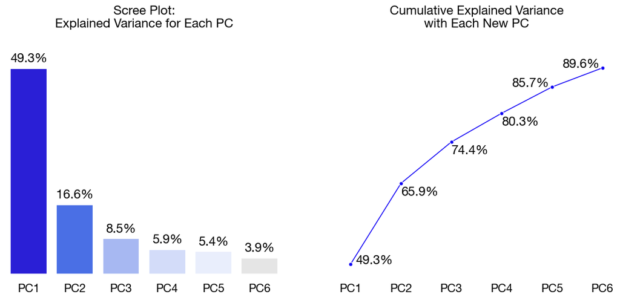

```python
# Variance explained by each component
explained_variance = pca.explained_variance_ratio_

explained_variance_df = pd.DataFrame({
    'Principal Component': [f'PC{i+1}' for i in range(pca.n_components_)],
    'Explained Variance': explained_variance,
    'Cum Variance': pd.Series(explained_variance).cumsum()
})

fig, axes = plt.subplots(1,2,figsize=(14,5))

sns.barplot(
    data=explained_variance_df,
    x='Principal Component',
    y='Explained Variance',
    ax=axes[0]
).set_title('Scree Plot:\nExplained Variance for Each PC\n\n')

sns.lineplot(
    data=explained_variance_df,
    x='Principal Component',
    y='Cum Variance',
    ax=axes[1],
    marker='o',
    size=3,
    markersize=5
).set_title('Cumulative Explained Variance\nwith Each New PC\n\n')

plt.legend([],[],frameon=False);

barlabels_1 = [f'{i*100:.1f}%' for i in explained_variance_df['Explained Variance']]
axes[0].bar_label(axes[0].containers[-1], label_type='edge', labels=barlabels_1, color='k', padding=5, rotation=0);


for x, y in zip(explained_variance_df['Principal Component'], explained_variance_df['Cum Variance']):
    if explained_variance_df['Principal Component'].tolist().index(x) == 0:
        axes[1].text(explained_variance_df['Principal Component'].tolist().index(x)+.1, y, f'{y*100:.1f}%')
    elif explained_variance_df['Principal Component'].tolist().index(x) <= 3:
        axes[1].text(explained_variance_df['Principal Component'].tolist().index(x), y-.025, f'{y*100:.1f}%')
    else:
        axes[1].text(explained_variance_df['Principal Component'].tolist().index(x)-.8, y, f'{y*100:.1f}%')


axes[0].set_xlabel('')
axes[1].set_xlabel('')
axes[0].set_ylabel('')
axes[1].set_ylabel('')

axes[0].set_yticklabels('');
axes[1].set_yticklabels('');
```

The scree plot shows *how much variability is captured by each Principal Component (PC)*. PC1 captures ~49%, PC2 ~17%, and so on. Each additional PC captures less and less variability (until you capture it all i.e. all coefficients add to 1), so the user needs to decide how many are enough to keep. There are a number of approaches to do this, but two common ones are the [elbow test](https://en.wikipedia.org/wiki/Scree_plot), and the 95% rule -- retain the PCs that capture 95% of the accumulated variance. This is why calculating and plotting the cumulative explained variance (right plot) is useful to decide. We can use 6 components, as PC6 already camptures less than 4%, meaning we are entering the zone of diminishing returns for capturing information in the dataset.

Nonetheless, since each row still corresponds to a car in the original dataset in an index-to-index fashion, we can leverage this to better explain the outputs of PCA in the later sections of this exercise.

## Eigenvalues, Eigenvectors, and Loading Scores

These are probably some of the most miunderstood terms in PCA.

Eigenvalues quantify the importance of each PC in capturing the variability of the data. The first eigenvalue (that of PC1) is always higher than the second, and so on. Eigenvalues are similar to the Explained Variance coefficients -- in fact they are proportional to them -- in the sense that higher values convey a higher proportion of the variability of the dataset contained in each PC, however unlike the coefficients they do *not* add to 1 or to 100.

```python
eigenvalues = pca.explained_variance_

pd.DataFrame({
    'Component': [f'PC{i+1}' for i in range(pca.n_components_)],
    'Eigenvalues': eigenvalues,
    'Explained Variance': explained_variance
})
```

|  | Component | Eigenvalues | Explained Variance |
| --- | --- | --- | --- |
| 0 | PC1 | 7.427482 | 0.492750 |
| 1 | PC2 | 2.505051 | 0.166189 |
| 2 | PC3 | 1.282823 | 0.085104 |
| 3 | PC4 | 0.891585 | 0.059149 |
| 4 | PC5 | 0.814024 | 0.054004 |
| 5 | PC6 | 0.590178 | 0.039153 |

Eigenvectors, on the other hand, are the singular vectors (unit 1 vectors) for each PC, and are made of Loading Scores representing the influence of each original variable over the PC. The higher the absolute value of the loading score, the higher the influence of the variable over each PC, and the sign (positive or negative) shows whether the variable "pushes" or "pulls" the vector alongside the new coordinate system relative to the origin. Your Eigenvectors, therefore, will have as many sclores as you had features in the original dataframe. This is why Eigenvectors (or each PC) are referred to as a *linear combinations* of the features in the original data (and therefore are **not** the original features themselves).

Eigenvectors are, in the end, n-dimensional singular vectors, where the "n" represents the number of dimensions in the original dataset (in this case 15).

Since we cannot plot (or interpret) a 15-dimension plot, it makes more intuitive sense to look at Eigenvectors and loading scores on a heatmap.

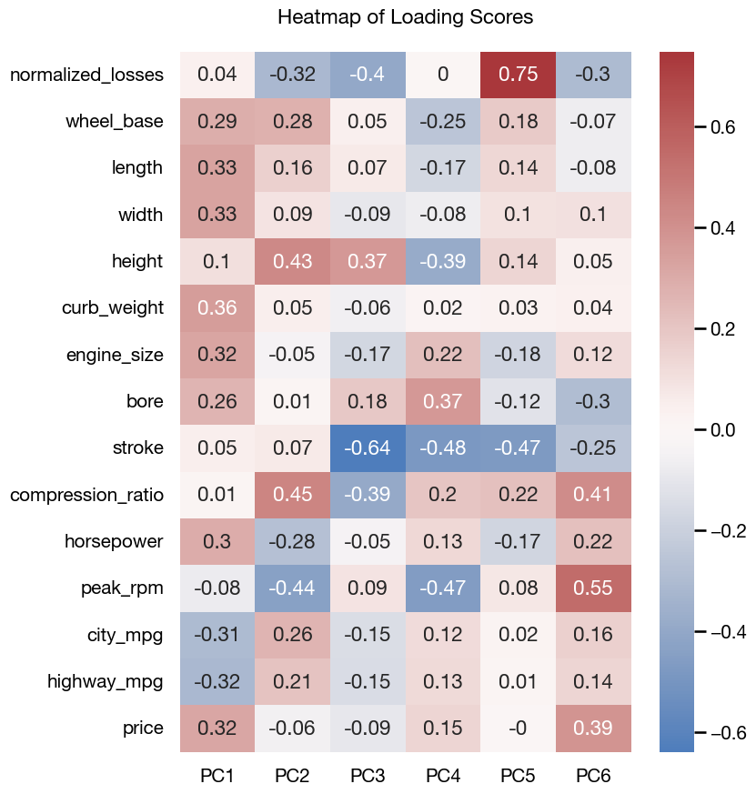

```python
eigenvectors = pca.components_
loading_scores = pd.DataFrame(eigenvectors.T, columns=[f"PC{i+1}" for i in range(eigenvectors.shape[0])], index=num_cols)

fig, axes = plt.subplots(1,1,figsize=(8,10))
sns.heatmap(
    loading_scores,
    annot=round(loading_scores,2),
    center=0,
    cmap='vlag',
    ax=axes
).set_title('Heatmap of Loading Scores\n');
```

With the heatmap above we can now better interpret PCs and loading scores, and how PCA captures variability in the original dataset.

PC1, for example, is mildly positively influenced by "size" variables (e.g. `length`, `curb_weight`), "power" (`horsepower`, `engine_size`), and value (`price`), but also mildly negatively influenced by "fuel efficiency" (`city_mpg`, `highway_mpg`). The relationship between these variables therefore appears when we consider that bigger, more powerful (and more expensive) cars tend to be less fuel efficient, and fuel efficient cars tend to be cheaper with smaller engines and packing less power. Therefore, we can infer that PC1 captures the size/power/efficiency trade-off dimension of the dataset.

The same exercise can be done for all PCs, but that is an exercise for the reader. One thing is critical, however: "naming" and interpreting PCs appropriately in context requires deep domain knowledge and familiarity with the dataset at hand. After all, PCs are **not** variables, but relationships between variables that are sometimes not straightforward to conceptualise and bring into lay language.

## PC Scatterplot and Biplot

The first thing that most people do is go straght into plotting the PCs they obtained using a scatterplot. The shape of the scatterplot for the PCs adds as a visual aid to make sense of how much variability was captured by each PC. In some extreme examples where PC1 captures 70%+ of variability and PC2 20%+ (e.g. [here](https://scikit-learn.org/stable/auto_examples/cross_decomposition/plot_pcr_vs_pls.html#sphx-glr-auto-examples-cross-decomposition-plot-pcr-vs-pls-py)) your scatterplot might look like a line with strong correlation between the main two PCs. In most cases, like in this example, however, the scatterplot will simply be a collection of points scattered around between the two PCs you chose to plot (usually the first two). Each point corresponds to one sample in the original dataset, and since their correspondence is on an index-to-index basis, we can leverage this to extract further information from the scatterplot but in the dimensionality-reduced space. The following plot shows fuel type for the original cars as additional information to the PC Scatterplot, as well as the make for some "extreme" cars in the PC1 sense:

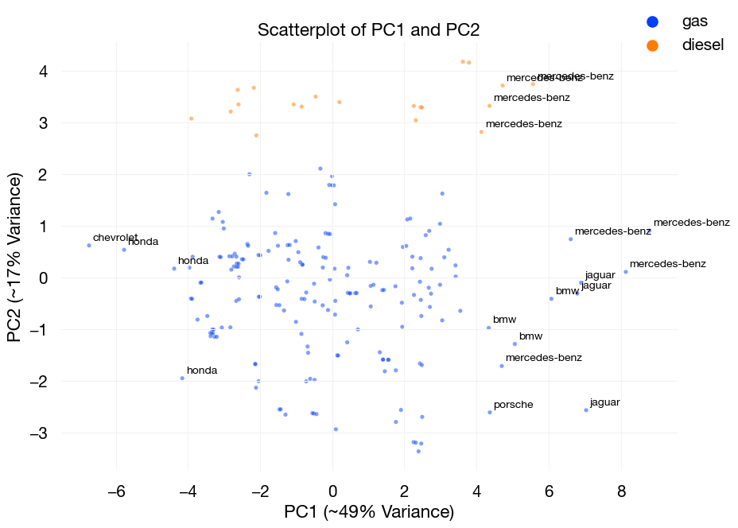

```python
X_pca_df = pd.DataFrame(X_pca, columns=[f'PC{i+1}' for i in range(pca.n_components_)])
X_pca_df_joined = X_pca_df.join(df, how='left')

fig, axes = plt.subplots(1,1,figsize=(10,7))

pc_x, pc_y = (0,1)
to_plot = X_pca_df_joined
cols = X_pca_df_joined.columns

sns.scatterplot(data=to_plot, x=cols[pc_x], y=cols[pc_y], ax=axes, s=15, alpha=.5, hue='fuel_type', palette='bright').set_title(f'Scatterplot of PC{pc_x+1} and PC{pc_y+1}')
axes.grid(True, color='#F2F2F2', zorder=0.5, linewidth=.8)

plt.xlabel(f"PC{pc_x + 1} (~{pca.explained_variance_ratio_[pc_x]*100:.0f}% Variance)")
plt.ylabel(f"PC{pc_y + 1} (~{pca.explained_variance_ratio_[pc_y]*100:.0f}% Variance)")

for x, y, make in zip(X_pca_df_joined['PC1'], X_pca_df_joined['PC2'], X_pca_df_joined['make']):
    if abs(x) > 4:
        plt.text(x+.1, y+.1, make, size=10)

plt.legend(bbox_to_anchor=(1.1,1.1)).get_frame().set_linewidth(0)
```

The Biplot is an extension of the PC scatterplot. In addition to the overall distribution of the samples in the dimensionality-reduced space, it shows the strength of each original variable alongside the components we chose to visualise. As you might have guessed, the concept is similar to combining the heatmap above with the scatterplot, but instead of colors to show strength, we use arrow lengths with the position of the arrow head corresponding to the (x,y) coordinates given by the loading scores of the relevant Eigenvector for the chosen PCs to plot):

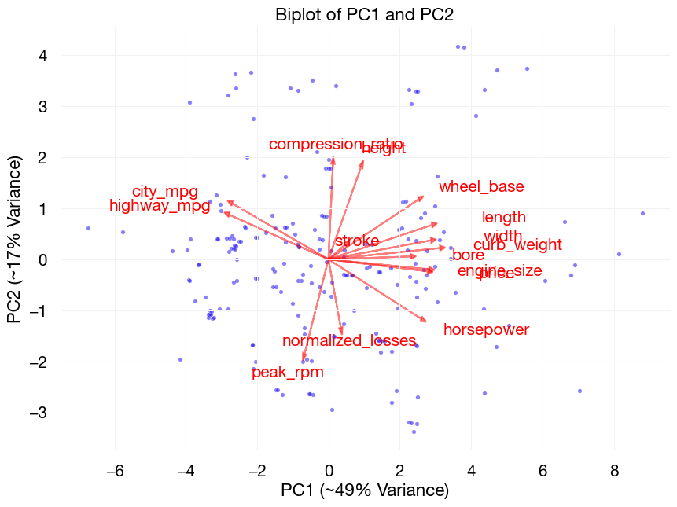

```python
def biplot(scores, loadings, labels, components=(0, 1), selected_labels=num_cols, feature_size=15, hue=None):
    """
    Creates a biplot for PCA.
    Args:
        scores: The PCA transformed data, in pandas df format.
        loadings: The loading scores (eigenvectors).
        labels: Feature labels.
        components: Tuple for the two principal components to plot.
        selected_labels: specific variables to include, defaults to all variables.
    """
    pc_x, pc_y = components
    cols=scores.columns

    fig, axes = plt.subplots(1,1,figsize=(10,7))

    # Scatter plot of the scores
    #sns.scatterplot(scores[:, pc_x], scores[:, pc_y], ax=axes, s=feature_size, alpha=.5).set_title(f'Biplot of PC{pc_x+1} and PC{pc_y+1}')
    sns.scatterplot(data=scores, x=cols[pc_x], y=cols[pc_y], ax=axes, s=feature_size, alpha=.5, hue=hue, palette='bright').set_title(f'Biplot of PC{pc_x+1} and PC{pc_y+1}')
    axes.grid(True, color='#F2F2F2', zorder=0.5, linewidth=.8)
    plt.xlabel(f"PC{pc_x + 1} (~{pca.explained_variance_ratio_[pc_x]*100:.0f}% Variance)")
    plt.ylabel(f"PC{pc_y + 1} (~{pca.explained_variance_ratio_[pc_y]*100:.0f}% Variance)")

    if hue:
        plt.legend(bbox_to_anchor=(1.1,1.1)).get_frame().set_linewidth(0)

    # Add the loading vectors
    for i, label in enumerate(labels):
        if label in selected_labels:
            plt.arrow(0, 0,
                        loadings[pc_x, i] * max(scores.iloc[:, pc_x]),
                        loadings[pc_y, i] * max(scores.iloc[:, pc_y]),
                        color='red', alpha=0.5, head_width=0.1)
            plt.text(loadings[pc_x, i] * max(scores.iloc[:, pc_x]) * 1.7,
                        loadings[pc_y, i] * max(scores.iloc[:, pc_y]) * 1.2,
                        label, color='red', ha='center', va='center', fontsize=15)

    plt.show()

# Call biplot
biplot(
    scores=X_pca_df_joined,
    loadings=eigenvectors,
    labels=num_cols,
    components=(0,1)
    )
```

The Biplot as it stands has some important limitations:

- The higher the number of original dimensions, the more difficult it is to read, and you can end up with a lot of overlapping text and arrows, obscuring some insights
- Not all original dimensions are important in the chosen PCs (e.g. in this case `stroke` has very low loading scores for the first two Eigenvectors)

Which is why the function above allows me to select only the features I am interested in exploring for the first two PCs.

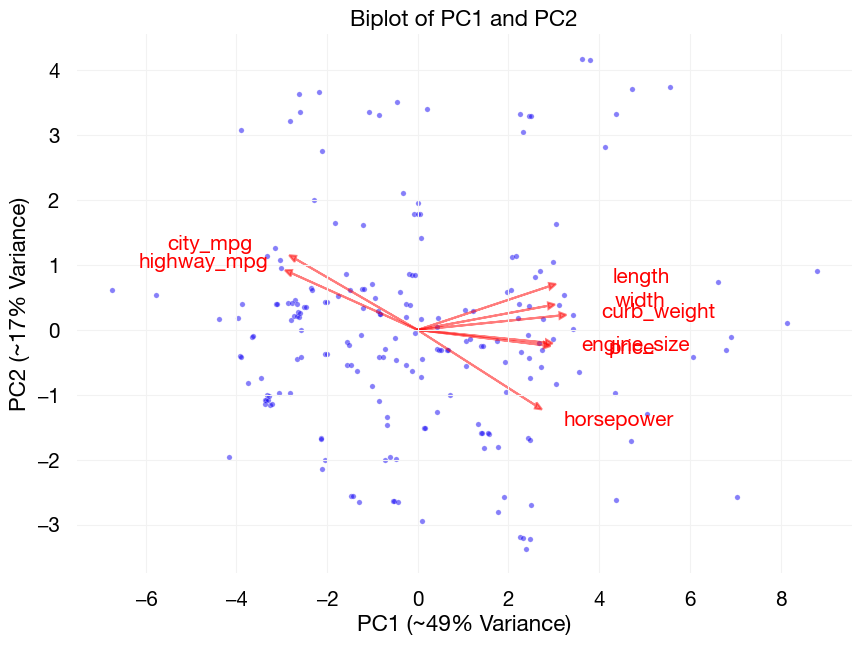

```python
pc1_2_cols = ['length','width','curb_weight','engine_size','horsepower','city_mpg','highway_mpg','price']

biplot(
    scores=X_pca_df_joined,
    loadings=eigenvectors,
    labels=num_cols,
    components=(0,1),
    selected_labels=pc1_2_cols
    )
```

Similar to what can be inferred from the heatmap, the more specific biplot also allows us to see that some of the "efficiency" information we captured in PC1 is captured by PC2, since the original features also have a mild component on PC2 (mind the scale differences though).

Finally, and to better drive the understanding of how the PCs capture data originally contained in the dataframe, we can add one of the dimensions of the original data to the dimensionality-reduced data and see how it matches the arrow of the biplot for the same dimension. If I add `horsepower` on top of the data and ask the function to match the point size to the horsepower, we get the following (note how I am scaling the variable for visual impact only).

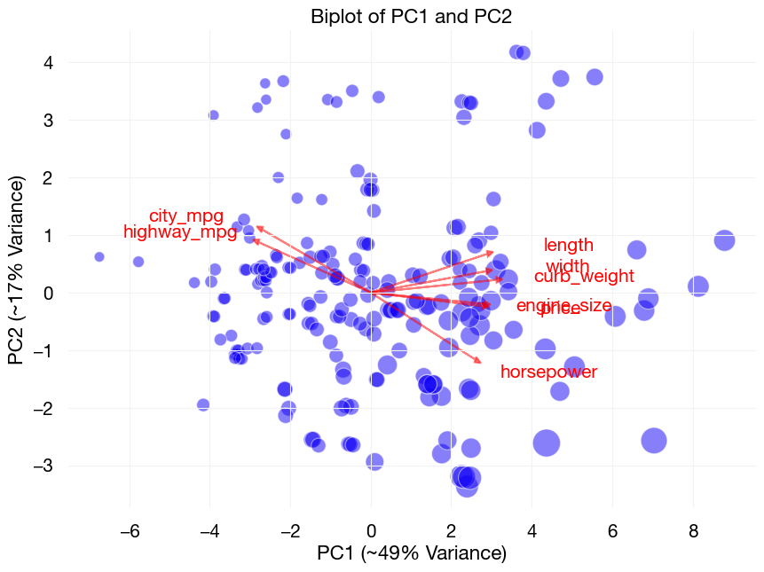

```python
biplot(
    scores=X_pca_df_joined,
    loadings=eigenvectors,
    labels=num_cols,
    components=(0,1),
    selected_labels=pc1_2_cols,
    feature_size=df_nums['horsepower']**1.1
    )
```

As we can see, the original `horsepower` data matches the direction and "strength" of the arrow. The same can be done with another variable of choice, in this case `city_mpg` (again, scaling for visual impact only):

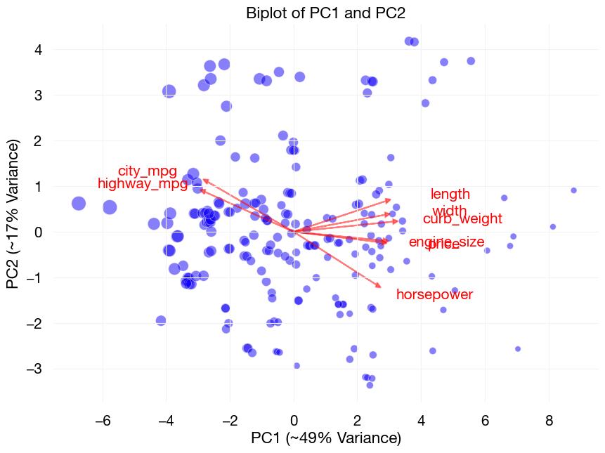

```python
biplot(
    scores=X_pca_df_joined,
    loadings=eigenvectors,
    labels=num_cols,
    components=(0,1),
    selected_labels=pc1_2_cols,
    feature_size=df_nums['city_mpg']**1.4
    )
```

And these are the main outputs and interpretations from PCA that I believe will interest your stakeholders the most!

If you have suggestions on how to further expand this short turorial, please do reach out. I hope you enjoyed reading it as much as I did developing it.